# Work Life Balance: Intramural Project

Anup

06/10/2021

### Motivation Of the Study

Health makes an important contribution to economic progress, as healthy population live longer, is more productive, and save more. Government expenditure on health is around 1% of GDP. This has resulted in inadequate financial protection in health and high out of pocket (OOP) - more than 62% of spending on health by Indians represents OOP and around 60 million people are pushed into poverty due to OOP. Relative low health outcomes with high burden of communicable diseases, including neglected tropical diseases, TB and a high risk of premature death due to NCDs. Weak public health system and sub-optimal capacities in surveillance and infection control(Strategy and DGO 2018). The Indian Health Care sector is prominently the largest and fastest growing sector in the country and it comprises of Hospital (71%)*, Pharmaceutical (13%), Diagnosis (3%), Medical equipment and supplies (9%) and medical insurance (4%). As per World Health Organization’s Global Health Workforce Statistics, OECD, supplemented by country data the physician (per 1000 people) is 0.93 and Nurses and midwives is 2.39 . The shortage of qualified medical professionals is one of the key challenges the Indian healthcare industry is facing . The health care sector totally relies in the hand of health care providers and undoubtedly, doctors and nurses are the dominant personnel in health care. Job stress among healthcare staff is becoming a common occurrence in most public health services. Work-life balance, burnout, and physician wellness have become an important focus over the last 20 years in the field of medicine. Significant work design and cultural changes are to blame for these newly recognized aspects of a physician’s career and life as a whole. Unique aspects of the work environment in the India not only contribute to these issues in the field of medicine, but also affect the Indian workforce at large. Stagnant responses from governmental bodies and private organizations have allowed the issue to worsen over time. Yet now, there is no hope for the necessary cultural change to address work-life balance, burnout, and physician wellness. Studies are available to identify the negative contributing factors, establish evidence-based prevention strategies, and help physicians to find their ideal work-life balance, avoid burnout, and achieve overall wellness (Battu and Chakravarthy 2014),(Lakshmi et al. 2012). This study seeks to provide a brief background in the area of work-life balance, burnout, and health care workers’ wellness. It will also review key points of the current literature and provide a combination of solutions suggested by experts in the field.

The daily work of physicians and nurses in the hospital setting is inherently stressful. Long workdays, excess case loads, time pressure, poor sleep habit, and high performance expectation contribute to the well-documented rates of burnout, depression, job dissatisfaction, and workplace fatigue among nurses and physicians. The consequences of these characteristics may include decreased patient satisfaction, diminished care quality, and increased rate of medical errors. Medical practitioners experience appreciable stress and are an at-risk profession of suicide. The lack of data on other health-care workers suggest to implement studies investigating those occupations(Dutheil et al. 2019). The main sources of stress that have been identified are: problems with practice administration, interruptions, patient’s expectations and demands, emergencies, heavy workload, constant time pressure and work/home conflictShanafelt et al. (2015). Health Care Personnel are often stressed with their own work which some where affects their family life in an adverse manner. The concept of work-life balance is going to be very appropriate for the healthcare professionals who are tend to work 24*7 and involve a lot strain and stress.

## Research Gap

After literature review it was found that there are many studies conducted in various fields and disciplines but there is a huge research gap on the study of work-life balance in health care sector in Indian perspective. Few studies has been carried out on this issue in Indian Health Care Sector, either focusing on nurses or doctors but not both together(Lakshmi et al. 2012). Hence, this is the peak time to take an in depth understanding on these issues which are not only desirable but also necessary. The present research tries to find out causes of imbalances among doctors and nurses. The results of the present study would be very useful to government and health care sector to understand the causes of distress and imbalance among the health care personnel and to make policies and strategies so that they can work with making an optimum blend of work and non-work domain, so that none of the domain prevails over the other.

## A Conceptual Framework of Work-Life Balance

“Work” and “Life” have been defined differently in literature (Guest 2002), where work is paid employment and life is everything outside of the formal employment but is usually used to connate the sphere of family or home life (Ransome 2007). WLB is defined as “satisfaction and good functioning at work and at home with a minimum of role conflict” (Clark 2000). WLB is defined as “the absence of unacceptable level of conflicts between work and non-work demands. (Greenblatt 2002) Work life balance as”the extent to which an individual is equally engaged in – and equally satisfied with – his or her work role and family role" (Greenhaus, Collins, and Shaw 2003). Work life balance is “the extent to which an individual’s effectiveness and satisfaction in work and family roles are compatible with the individual’s life priorities. (Greenhaus, Allen, and Spector 2006) Work–family balance is defined”as accomplishment of role related expectations that are negotiated and shared between an individual and his or her role-related partners in the work and family domains" (Grzywacz and Carlson 2007). WLB for any person is having the “right” combination of participation in paid work (defined by hours and working conditions) and other aspects of lives. This combination will change as people move through life and have changing responsibilities and commitments in their work and personal lives (Frone, Russell, and Cooper 1992). With these definitions it is clear that any imbalance that is formed either creates more pressure or psychological involvement or satisfaction towards one role as compared to other role. Work is an important source of income, financial stability and status. As work and family has no direct relationship with each other so conflicts is inevitable to arise. Work and family are not independent of each other rather have an interlink which consequently brings in conflicts between the two. There was a general consensus formed that work and family affect each other either in a positive or negative way. And there are various extraneous variables like time, task, attitudes, stress emotions, and behaviors which have an influence over work life imbalance. (Carlson 2003) discussed about the psychological involvement of the person in the organization as well as on the family front. A high degree of psychological involvement with context to role of an individual i.e. job role and family role would prioritize the individual to be somewhat mentally preoccupied with their performance in that role, such imbalance in performance will have significant implications on work to family and family to work interference. Conceptually, it seems evident that psychological involvement would have significant implications for levels of work to family and family to work interference. (Carlson 2003)found that both psychological involvement and behavioral (time) involvement were significant related to WIF but the reverse did not apply with FIW or family involvement into work. Clearly more research and dynamic interplay in relationship of time and family was required to draw conclusions. Therefore, (Frone 2003) summarized the findings from US based survey and noted that family boundaries may be more permeable than job boundaries and hence the levels of work to family (WFI) interference are reported higher or more intense than those of family to work interference (FWI).

### OBJECTIVES OF THE STUDY

The objectives framed for the study are as follows:

1. To explore the variations in work-life balance indicators in the Indian and Global context;
2. To identify the important variables related to work-life balance in Health Care Sector (Hospitals);
3. To measure the dependency of work-family conflict and family-work conflict on control variables;
4. To examine the existing work-life balance variables among doctors and nurses; and 5. To assess the impact of work-life balance variables on job satisfaction, employee well- being and stress control.

### HYPOTHESES FORMULATION

On the basis of literature review and above objectives the following hypotheses are laid down:

- $H_01$: There is no variation in work-life balance variables in the Private and Government institute.
- $H_02$: There is no dependency of work-family conflict and family-work conflict on control variables;
- $H_01$: There is no significant relationship of work-life balance variables among doctors and nurses; and
- $H_01$: Work-Life Balance variables do not significantly impact the job satisfaction, employee well-being and stress control.

Proposed Research Model: The present model comprises of four aspects i.e., Work-Life Balance Variables, Control Variables, Conflict Measurement and Outcome Variables. The proposed research model depicts the dependency of work-family conflict and family-work conflict on control variables, the existing work-life balance variables among doctors and nurses and the impact of work-life balance variables on job satisfaction, employee well-being and stress control.

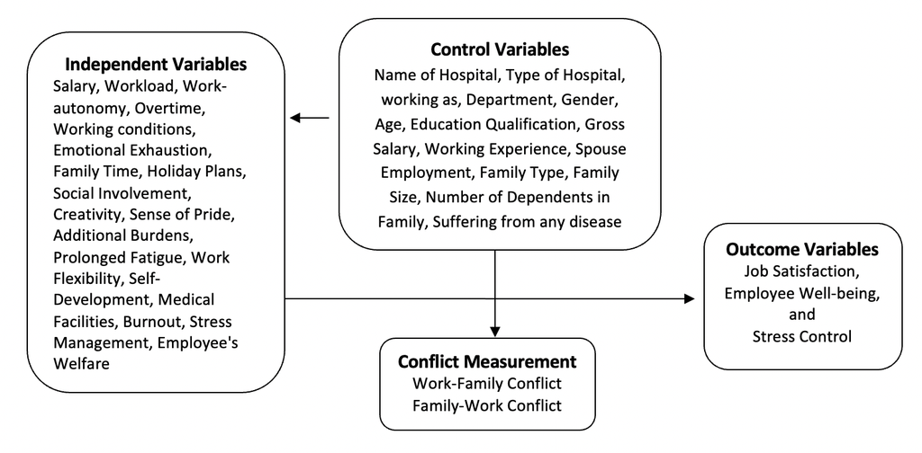

# **Significance of the Study:**

Work life balance is described as people who control and manage see-saw of both life and career with achievement and satisfaction**.** It is the term used to describe those practices at workplace that acknowledge and aim to support the needs ofemployees in achieving a balance between demands of their family and work life. Work life balance means adjusting the pattern of work so that the employee can benefit from a better fit between their work and areas of their personal life and in long run hope to achieve sustainable development and profitability . Finding an equal balance between work and life is the biggest challenge women face today. According to a poll of 500 Canadian female managers and executives, the majority of women today agreed that balancing work and home life is difficult for females in leadership roles. Work domain and family domain has been identified as causesof work-life conflict. (Greenhaus and Beutell 1985) has defined as inter-role conflict in which pressure from the work domain and family domain are mutually mismatched that is participation in one role made difficult for women employee to perform the responsibility ofanother role and they have also claimed that work life conflict increases whenpeople have to perform multiple roles, which often lead to overloads andinterferences. Hence, professional women often experience a role overload dueto high energy and time requirements and the commitment to family and work. Itwas found that long working hour, work overload, overtime, unsupportivesupervisor as work issues interfered family life and on the other hand child care, elder care, unsupportive family member was found as family issue which interfered work life. Thus, both lives have been affected with each other. (Lakshmi et al. 2012)(Liu et al. 2021) examined in their study the effect of work life balance on women’s performance and work attitude and also determined the factors affecting work life balance by taking the data from 30 women employees with reference to teaching faculties belonging to various disciplines. It was found that marital status, additional working hours, requirement of flexibility, number of dependents, childcare and overtime etc. were the various factors which affected the work life balance of women employees. Due to the COVID-19 pandemic the health care workers are also termed as front line workers and they are put under immense harsh condition to work. The Intersection of Work and Home Challenges Faced by Physician Mothers during the Coronavirus Disease 2019 Pandemic is studied by (Halley et al. 2021). Perceptions of Work-Life Balance before and since the COVID-19 Pandemic is also studied by (Matulevicius et al. 2021).

The present study is carried in Lucknow district , which is a “Medical Hub” of state Uttar Pradesh in India. People from various regions prefer the medical institutions like Sanjay Gandhi Postgraduate Institute of Medical Sciences and King George Medical University, Ram Manohar Lohia Medical University etc. for treatment and various other recognized hospitals like Medanata and Appolo for their treatment. Lucknow as a district have maximum number of Medical College in Uttar Pradesh. The number of patient from nearby districts and other states are coming to Lucknow for better medical treatment. Consequently, hospitals are overburdened and it is quite challenging to manage health issues of numerous patients. There is no proper study conducted to access the work-life balance of the medical practitioners in these medical colleges. The study tries to find out causes of imbalances among doctors and nurses. The results of the present study would be very useful to Government and Private medical instititions to understand the causes of distress and imbalance among the health care personnel and to make policies and strategies so that they can work with making an optimum blend of work and non-work domain, so that none of the domain prevails over the other.

# Study Setting and Data Collection Tool

There are eight medical institution in Lucknow District. Sanjay Gandhi Postgraduate Institiue of Medical Sciences, Dr. Ram Manohar Lohia Institite of Medical Sciences, King George Medical University are three Goverenment Institutions, whereas rest five, Career, Era, Integral, Prasad and TS Mishra medical institutions are private medical colleges. SGPGI have only facility of PG and post PG courses, where are others also have undergraduate courses.

## Research Design: Research Design for the study is divided into the following parts:

### Scope of the Study

|  | Working_as Doctor | Working_as Paramedics |
| --- | --- | --- |
| Name_Hosp |  |  |
| Career IMS | 20 | 33 |
| Era IMS | 20 | 31 |
| Integral IMS | 26 | 30 |
| KGMU | 62 | 58 |
| Prasad IMS | 20 | 31 |
| RMLIMS | 43 | 55 |
| SGPGI | 23 | 54 |
| TSMIMS | 20 | 33 |
| #Total cases | 234 | 325 |

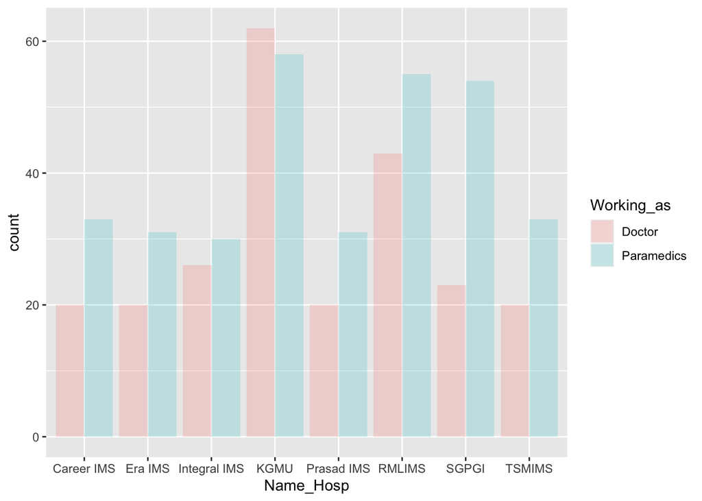

## Method Design

### Type of Data

Primary and Secondary data would be used in the present study.

### Sources of Data Collection

The relevant data would be collected from two sources i.e. primary and secondary sources.

### Questionnaire

An integrated digital questionnaire is prepared compiling the work-life balance questionnaire contents with demographic information of doctors and nurses/paramedical staff working in hospital.

### Personal Interviews

For in depth study, personal interviews would also be arranged with doctors and nurses/paramedical staff working in hospital. Observation: For cross checking of facts the spot observation method would also be introduce in the study.

### Secondary Information

Secondary Data would be collected from published data and various journals, Reports Official Statistics, Different books, Magazines, Research Papers, Reports, Articles, publications. Internet and electronic data would also be concerned as the source of secondary information.

### Research Tool (Questionnaire)

To access the status of work life balance in HCW of these institutions a questionnaire is framed.An integrated questionnaire is prepared compiling the work-life balance related statements with demographic information of doctors and nurses working in hospital. The questionnaire comprises of four sections. The First Section is focused to gather information about respondents profile through fifteen statements. The Second section consists of Nineteen Work-Life Balance Variables. The third section is based on conflict measurement comprising of work-family conflict and family-work conflict each having four statements. Finally, the fourth section includes three outcome variables. A data collections agency is hired for the cross sectional survey. Trained survey field investigators are send to these medical institutions for data collection.

## Sampling Strategy

### Sampling Frame

The total population of this study shall comprise all those doctors and nurses/paramedical staff of SGPGIMS, KGMU, RMLU and other five Private Institution in Lucknow District. Sampling Unit The sampling unit shall consist of 03 public and 05 private institution/hospitals (Total 08 ) in Lucknow District.

### Sample size determination:

For determining the sample size it is assumed that 30% of the HCW have good work life balance.
$$n = \frac{z^2_{\alpha/2} p q}{d^2}$$
assuming $p = 0.3$ and $ d = 0.05$, the value of $n = 322$. Assuming design effect of 1.5 the adjusted sample size is 483. Hence it was decided to collect data from at least from 500 respondent in these eight medical institutions.

# Result and Findings

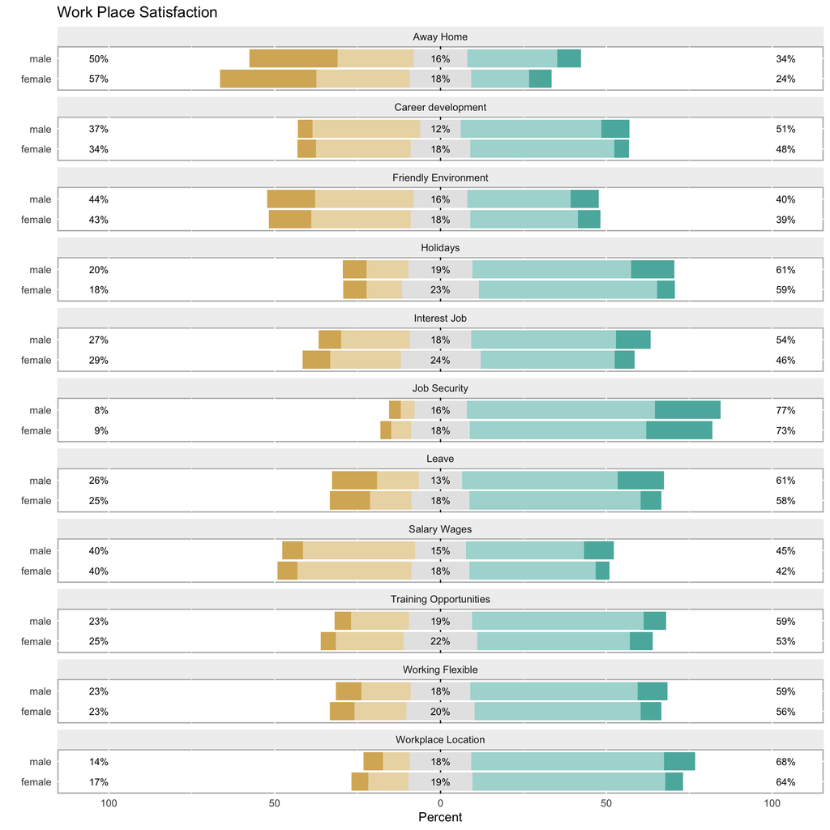

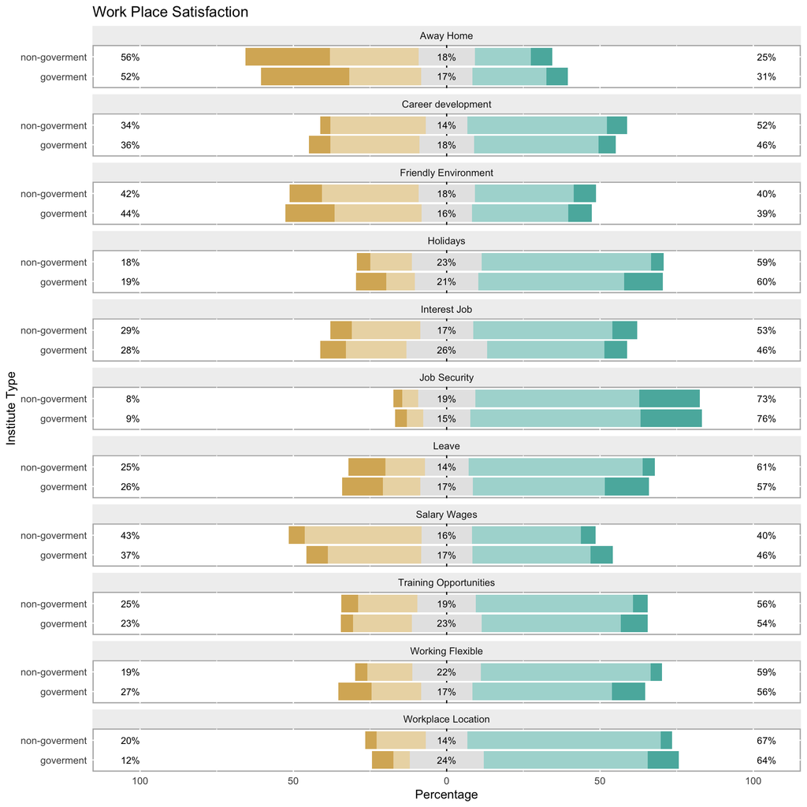

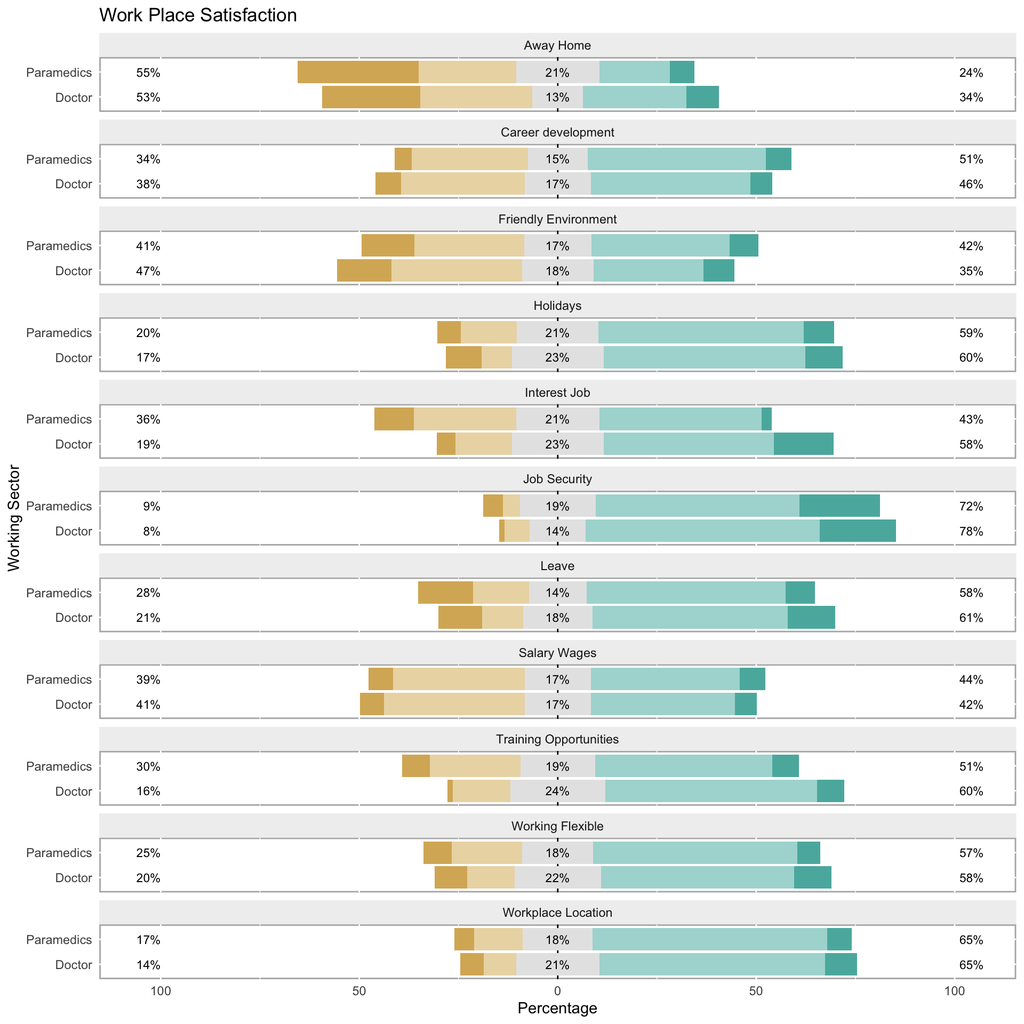

```r
data12 <- data[,27:33]
data12 <-  as.data.frame(data12)
names(data12) = c("Ability Untilization","Coworkers","Supervisor","Working Conditions","Medical Facilities","Work Autonomy","Employe Welfare" )

result_wpfs <- likert(data12)
```

```r
library(xtable)
library(kableExtra)
print(xtable(result_wpfs, caption="My table using xtable package", label="xtabletab"), comment=FALSE,
            caption.placement="top", type="html")
```

| Item | n | mean | sd | low | neutral | high |
| --- | --- | --- | --- | --- | --- | --- |
| Ability Untilization |  | 3.56 | 0.86 | 14.13 | 18.07 | 67.80 |
| Medical Facilities |  | 3.62 | 0.81 | 10.38 | 22.72 | 66.91 |
| Work Autonomy |  | 3.51 | 0.99 | 19.86 | 18.43 | 61.72 |
| Supervisor |  | 3.28 | 0.99 | 24.87 | 22.54 | 52.59 |
| Working Conditions |  | 3.25 | 1.00 | 27.19 | 22.18 | 50.63 |
| Coworkers |  | 3.16 | 0.98 | 32.56 | 18.78 | 48.66 |
| Employe Welfare |  | 3.14 | 1.04 | 34.53 | 18.43 | 47.05 |

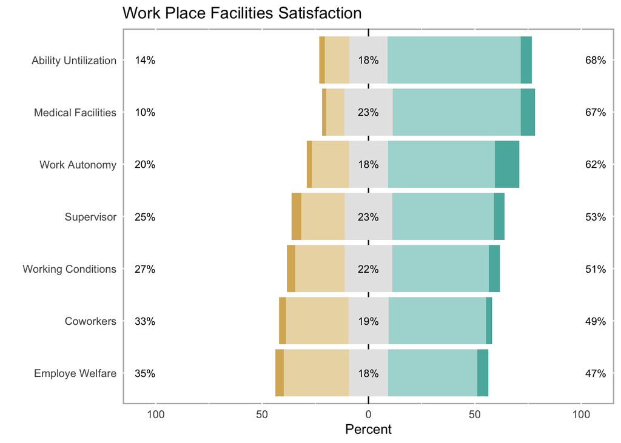

```r
plot_wpfs <- plot(result_wpfs, centered=TRUE, type = "bar", legend = "") + labs(title = "Work Place Facilities Satisfaction", y = "Percent")

plot_wpfs
```

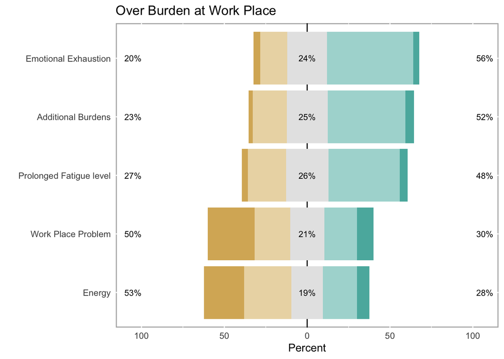

```r
data13 <- data[,c(34:36,50,52)]
data13 <-  as.data.frame(data13)
names(data13) = c("Emotional Exhaustion","Prolonged Fatigue level","Additional Burdens","Energy","Work Place Problem" )




result_obwp <- likert(data13)
plot_obwp  <- plot(result_obwp , centered=TRUE, type = "bar", legend = "") + labs(title = "Over Burden at Work Place", y = "Percent")
plot_obwp
```

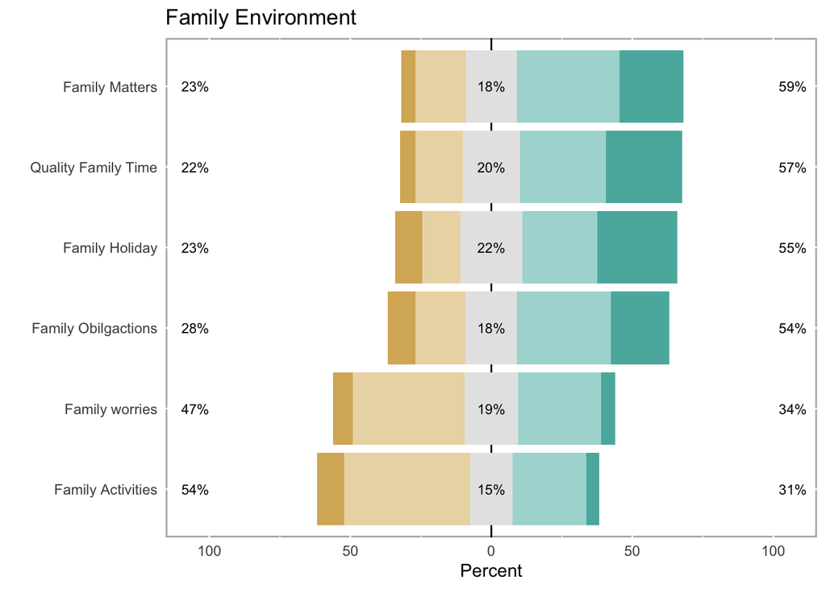

```r
data14 <- data[,c(37,38,45:48)]
data14 <-  as.data.frame(data14)
names(data14) = c("Family worries","Family Activities","Family Obilgactions","Family Matters","Quality Family Time","Family Holiday" )


result_FE <- likert(data14)
plot_FE   <- plot(result_FE  , centered=TRUE, type = "bar", legend = "") + labs(title = "Family Environment", y = "Percent")
plot_FE
```

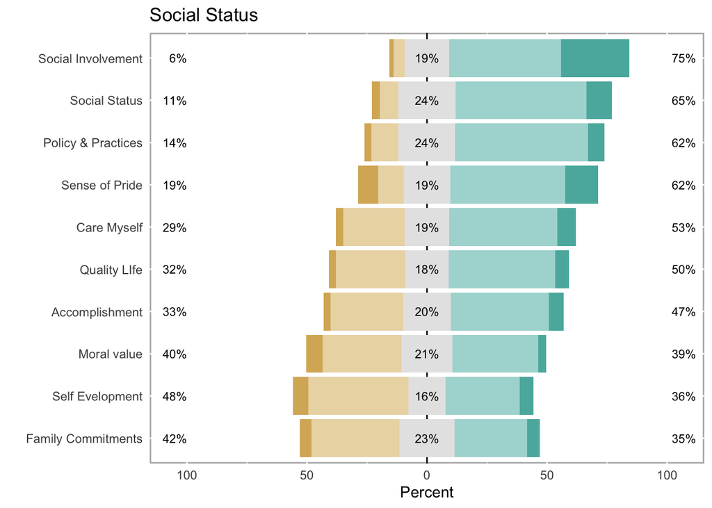

```r
data15 <- data[,c(53:56,39:44)]
data15 <-  as.data.frame(data15)
names(data15) = c("Sense of Pride","Social Status","Policy & Practices","Accomplishment","Self Evelopment","Moral value","Family Commitments","Social Involvement","Quality LIfe","Care Myself" )

result_Ss <- likert(data15)
plot_Ss   <- plot(result_Ss  , centered=TRUE, type = "bar", legend = "") + labs(title = "Social Status", y = "Percent")
plot_Ss
```